# **Data Challenge MDI-343 2019/2020**

*Thomas Koch*

# **Abstract**

*Version française*

Ceci est le notebook de mon travail sur le Data Challenge MDI-343 2019/2020. Quelques commentaires se trouvent au fil du code. Beaucoup de choses ont été tentées bien que toutes ne figurent pas dans ce notebook. De même, toutes les tentatives n'ont pas fait l'objet de soumissions.

Ce Data Challenge n'était pas simple dans la mesure où d'une part, la métrique proposée était très stricte (et très intéressante également), et d'autre part, il semble que le jeu de test ait des différences avec le jeu de train puisque nous perdions quasi systématiquement tous 10 points de score entre notre évaluation sur une partie des données d'entraînement (mises de côtés pour cela) et l'évaluation sur le jeu de test de la soumission.

N'ayant pas réussi à comprendre d'où venait cette différence et comment y remédier, la seule option pour parvenir à faire un score convenable était de faire tourner encore et encore mon XGBOOST pour trouver les meilleurs paramètres. N'ayant pas vu grand intérêt à cela, j'ai utilisé cette technique une fois pour voir ce que cela donnait mais ne me suis pas plus acharné dessus.

Il aurait sans doutes été possible de faire un meilleur score en affinant encore et encore la recherche des hyperparamètres avec le code de ce notebook mais j'ai préféré me concentrer sur la recherche de techniques probantes dans le preprocessing des données. Cela n'a toutefois pas fonctionné et explique donc le faible nombre de soumission effectué (10 au total).

Les approches utilisées pour préprocesser les données, notamment la PCA, n'ont en effet pas permis de donner des résultats satisfaisant. La vraie plus value se situait surtout au niveau des temps de calculs puisque moins de paramètres étaient à prendre en compte et les entraînements étaient donc plus rapides.

Finalement, **les meilleurs résultats ont été obtenus avec la star des algorithme de ML : XGBoost**. De plus **ces résultats ont été obtenus avec les données d'entraînement brutes**. Une autre bonne alternative aurait été d'utiliser **Light GBM (Light Gradient Boosting Method)**, qui aurait certainement eu de très bon résultats et une meilleure performance qu'un XGBoost par rapport à la taille de notre dataset (*qui avait le mérite d'être propre puisque dénué de NaN ou de valeurs abhérentes*).

*English version*

This is the notebook for my work on the Data Challenge MDI-343 2019/2020. Some comments are found throughout the code. Many things have been attempted, although not all of them are included in this notebook. Likewise, not all attempts were subject to bids.

This Data Challenge was not simple insofar as on the one hand, the proposed metric was very strict (and very interesting also), and on the other hand, it seems that the test game has differences with the game of train since we almost always lost all 10 score points between our evaluation on a part of the training data (set aside for that) and the evaluation on the test game of the submission.

Not having managed to understand where this difference came from and how to remedy it, the only option to achieve a suitable score was to run my XGBOOST again and again to find the best parameters. Not having seen much interest in this, I used this technique once to see what it looked like but did not get more serious about it.

It would undoubtedly have been possible to make a better score by refining again and again the search for hyperparameters with the code of this notebook but I preferred to concentrate on the search for convincing techniques in the preprocessing of the data. However, this did not work and therefore explains the low number of submissions made (10 in total).

The approaches used to preprocess the data, in particular the PCA, has not produced satisfactory results. The real added value was mainly in terms of calculation times since fewer parameters had to be taken into account and the training sessions were therefore faster.

Finally, **the best results were obtained with the star of the ML algorithm: XGBoost**. Besides **these results were obtained with the raw training data**. Another good alternative would have been to use **Light GBM (Light Gradient Boosting Method)**, which would certainly have had very good results and better performance than an XGBoost compared to the size of our dataset (*which had the merit of being clean since it is devoid of NaN or aberrant values*).

# **Introduction**

## Challenge Large Scale Machine Learning

### Authors:

#### Pavlo Mozharovskyi (pavlo.mozharovskyi@telecom-paris.fr), Umut Şimşekli (umut.simsekli@telecom-paris.fr)

### Fusion of algorithms for face recognition

The increasingly ubiquitous presence of biometric solutions and face recognition in particular in everyday life requires their adaptation for practical scenario. In the presence of several possible solutions, and if global decisions are to be made, each such single solution can be far less efficient than tailoring them to the complexity of an image.

In this challenge, the goal is to build a fusion of algorithms in order to construct the best suited solution for comparison of a pair of images. This fusion will be driven by qualities computed on each image.

Comparing of two images is done in two steps. 1st, a vector of features is computed for each image. 2nd, a simple function produces a vector of scores for a pair of images. The goal is to create a function that will compare a pair of images based on the information mentioned above, and decide whether two images belong to the same person.

You are provided a label set of training data and a test set without labels. You should submit a .csv file with labels for each entry of this test set.

# **The properties of the dataset**

## Training data

File **xtrain_challenge.csv** contains one observation per row which contains following entries based on a pair of images:

- columns 1-13 - 13 qualities on first image;
- columns 14-26 - 13 qualities on second image;
- columns 27-37 - 11 matching scores between the two images.

File **ytrain_challenge.csv** contains one line with each entry corresponding to one observation in **xtrain_challenge.csv**, maintaining the order, and has '1' if a pair of images belong to the same person and '0' otherwise.

## Test data

File **xtest_challenge.csv** has the same structure as file **xtrain_challenge.csv**.

There are in total 3,768,311 test observations.

## The performance criterion

Consider the problem of the supervised classification with two classes labeled '0' and '1'. Many methods for supervised classification assign a new observation $\boldsymbol{x}$ to a class using the following rule:

\begin{align} g(\boldsymbol{x}) = \begin{cases}1 & \text{ if } f(\boldsymbol{x}) \ge t, \\ 0 & \text{ otherwise}.\end{cases} \end{align}

Threshold $t$ is then chosen due to specific needs managing the trade-off between the true positive rate (TPR) and the false positive rate (FPR), depending on the cost of the corresponding mistakes.

Here, the performance criterion is **TPR for the value of FPR = $10^{-4}$**, or, speaking in other words, one needs to maximize the value of the receiver operating characteristic (ROC) in the point FPR = $10^{-4}$. The submitted solution file should thus contain the score for each observation.

# **Training Data**

Training data, input (file **xtrain_challenge.csv**):

https://www.dropbox.com/s/618rb0wev4q84kj/xtrain_challenge.csv

Training data, output (file **ytrain_challenge.csv**):

https://www.dropbox.com/s/oph3w9sn3nmu376/ytrain_challenge.csv

# **Test Data**

Test data, input (file **xtest_challenge.csv**):

https://www.dropbox.com/s/fezxb6lrzass556/xtest_challenge.csv

```python
from google.colab import drive
drive.mount('/content/drive')
```

```
Go to this URL in a browser: https://accounts.google.com/o/oauth2/auth?client_id=947318989803-6bn6qk8qdgf4n4g3pfee6491hc0brc4i.apps.googleusercontent.com&redirect_uri=urn%3aietf%3awg%3aoauth%3a2.0%3aoob&response_type=code&scope=email%20https%3a%2f%2fwww.googleapis.com%2fauth%2fdocs.test%20https%3a%2…

Enter your authorization code:
··········
```

# **Imports**

```python
%matplotlib inline
import numpy as np
import pandas as pd
import sys
import os
import math

import matplotlib.pyplot as plt
import seaborn as sns

from sklearn.linear_model import LogisticRegression
from sklearn.model_selection import train_test_split
from sklearn.utils import shuffle
```

# **Load and investigate the data**

```python
# Load training data with pandas
path = '/content/drive/My Drive/Colab Notebooks/Data Challenge/'
xtrain = pd.read_csv(path+'xtrain_challenge.csv', delimiter=',', skiprows = 1, header=None)
ytrain = pd.read_csv(path+'ytrain_challenge.csv', delimiter=',', skiprows = 1, header=None)


# Check the number of observations and properties
print(xtrain.iloc[:3,])
print()
print(ytrain[:10])
print()
print(xtrain.shape)
print()
print(ytrain.shape)
```

```
    0    1    2      3      4   ...       32       33       34       35       36
0  1.0  0.0  0.0  -6.24  -5.27  ...  2118.77  2580.99  2498.04  3180.58  2718.29
1  1.0  0.0  0.0  -0.42  -4.50  ...  2689.42  3763.51  2544.22  3515.58  3247.49
2  1.0  0.0  0.0  33.76 -19.29  ...  1644.05  2308.05  1774.88  3005.79  2507.02

[3 rows x 37 columns]

   0
0  0
1  0
2  0
3  0
4  0
5  0
6  0
7  0
8  0
9  1

(9800713, 37)

(9800713, 1)
```

```python
xtrain.describe()
```

|  | 0 | 1 | 2 | 3 | 4 | 5 | 6 | 7 | 8 | 9 | 10 | 11 | 12 | 13 | 14 | 15 | 16 | 17 | 18 | 19 | 20 | 21 | 22 | 23 | 24 | 25 | 26 | 27 | 28 | … |
| --- | --- | --- | --- | --- | --- | --- | --- | --- | --- | --- | --- | --- | --- | --- | --- | --- | --- | --- | --- | --- | --- | --- | --- | --- | --- | --- | --- | --- | --- | --- |
| count | 9.800713e+06 | 9.800713e+06 | 9.800713e+06 | 9.800713e+06 | 9.800713e+06 | 9.800713e+06 | 9.800713e+06 | 9.800713e+06 | 9.800713e+06 | 9.800713e+06 | 9.800713e+06 | 9.800713e+06 | 9.800713e+06 | 9.800713e+06 | 9.800713e+06 | 9.800713e+06 | 9.800713e+06 | 9.800713e+06 | 9.800713e+06 | 9.800713e+06 | 9.800713e+06 | 9.800713e+06 | 9.800713e+06 | 9.800713e+06 | 9.800713e+06 | 9.800713e+06 | 9.800713e+06 | 9.800713e+06 | 9.800713e+06 | … |
| mean | 9.918364e-01 | 5.252516e-03 | 2.858537e-03 | -2.243750e-01 | -5.766788e+00 | -7.422710e-01 | 1.264598e+00 | 9.991708e-01 | 8.592701e-01 | 2.561005e+02 | 3.765261e+01 | 1.873179e-01 | 7.033070e-01 | 9.973434e-01 | 4.288885e-03 | 1.506325e-03 | -2.001280e-01 | -5.787821e+00 | -7.621272e-01 | 1.220221e+00 | 9.554807e-01 | 8.160231e-01 | 2.685604e+02 | 3.806021e+01 | 1.780925e-01 | 7.260753e-01 | 2.421924e+03 | 2.294543e+03 | 2.619504e+03 | … |
| std | 6.377177e-02 | 5.143305e-02 | 3.607721e-02 | 9.952588e+00 | 8.868902e+00 | 4.565691e+00 | 1.158636e+00 | 8.948037e-01 | 7.733346e-01 | 7.512713e+01 | 1.340483e+01 | 3.895149e-01 | 4.488369e-01 | 6.843035e-01 | 6.149545e-01 | 2.342733e-02 | 8.445116e+00 | 8.351429e+00 | 4.387539e+00 | 1.095457e+00 | 8.642092e-01 | 8.188959e-01 | 7.496497e+01 | 1.359784e+01 | 3.821111e-01 | 4.375053e-01 | 1.036611e+03 | 9.535095e+02 | 1.260018e+03 | … |
| min | 0.000000e+00 | 0.000000e+00 | 0.000000e+00 | -7.820000e+01 | -6.771000e+01 | -3.482000e+01 | 0.000000e+00 | 0.000000e+00 | 0.000000e+00 | -2.980000e+02 | 1.842000e+01 | 0.000000e+00 | 0.000000e+00 | 0.000000e+00 | 0.000000e+00 | 0.000000e+00 | -5.476000e+01 | -4.213000e+01 | -2.640000e+01 | 0.000000e+00 | 0.000000e+00 | 0.000000e+00 | -2.980000e+02 | 1.846000e+01 | 0.000000e+00 | 0.000000e+00 | 0.000000e+00 | 8.100200e+02 | 6.218300e+02 | … |
| 25% | 1.000000e+00 | 0.000000e+00 | 0.000000e+00 | -3.220000e+00 | -1.263000e+01 | -2.850000e+00 | 4.700000e-01 | 3.500000e-01 | 3.100000e-01 | 2.112600e+02 | 2.580000e+01 | 0.000000e+00 | 1.000000e-02 | 1.000000e+00 | 0.000000e+00 | 0.000000e+00 | -2.580000e+00 | -1.242000e+01 | -2.750000e+00 | 4.500000e-01 | 3.300000e-01 | 2.900000e-01 | 2.246100e+02 | 2.578000e+01 | 0.000000e+00 | 4.000000e-02 | 1.895080e+03 | 1.778460e+03 | 2.021020e+03 | … |
| 50% | 1.000000e+00 | 0.000000e+00 | 0.000000e+00 | -1.000000e-02 | -4.870000e+00 | -6.000000e-01 | 1.000000e+00 | 7.600000e-01 | 6.700000e-01 | 2.641500e+02 | 3.449000e+01 | 0.000000e+00 | 1.000000e+00 | 1.000000e+00 | 0.000000e+00 | 0.000000e+00 | 5.000000e-02 | -4.910000e+00 | -6.400000e-01 | 9.600000e-01 | 7.200000e-01 | 6.400000e-01 | 2.774100e+02 | 3.521000e+01 | 0.000000e+00 | 1.000000e+00 | 2.150870e+03 | 2.045510e+03 | 2.278870e+03 | … |
| 75% | 1.000000e+00 | 0.000000e+00 | 0.000000e+00 | 3.140000e+00 | 9.600000e-01 | 1.430000e+00 | 1.740000e+00 | 1.380000e+00 | 1.190000e+00 | 3.091400e+02 | 4.807000e+01 | 0.000000e+00 | 1.000000e+00 | 1.000000e+00 | 0.000000e+00 | 0.000000e+00 | 2.610000e+00 | 7.600000e-01 | 1.240000e+00 | 1.690000e+00 | 1.320000e+00 | 1.130000e+00 | 3.216900e+02 | 4.895000e+01 | 0.000000e+00 | 1.000000e+00 | 2.508110e+03 | 2.425350e+03 | 2.650590e+03 | … |
| max | 1.000000e+00 | 1.000000e+00 | 1.000000e+00 | 5.934000e+01 | 2.668000e+01 | 6.482000e+01 | 3.873000e+01 | 1.568000e+01 | 2.442000e+01 | 4.704700e+02 | 7.677000e+01 | 1.000000e+00 | 1.000000e+00 | 2.602500e+02 | 2.331300e+02 | 9.800000e-01 | 5.108000e+01 | 2.277000e+01 | 2.474000e+01 | 3.001000e+01 | 9.430000e+00 | 1.452100e+02 | 1.611470e+03 | 7.677000e+01 | 1.000000e+00 | 1.000000e+00 | 1.086754e+04 | 1.058265e+04 | 1.497820e+04 | … |

```python
ytrain.describe()
```

|  | 0 |
| --- | --- |
| count | 9.800713e+06 |
| mean | 6.867378e-02 |
| std | 2.528986e-01 |
| min | 0.000000e+00 |
| 25% | 0.000000e+00 |
| 50% | 0.000000e+00 |
| 75% | 0.000000e+00 |
| max | 1.000000e+00 |

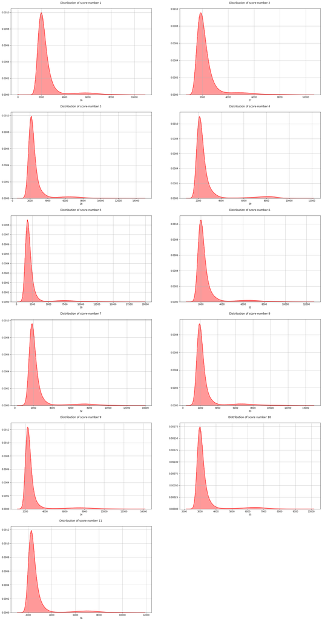

```python
plt.figure(figsize=(25,50))
for i in range(1,12):
    plt.subplot(6,2,i)
    sns.distplot(xtrain[25+i], bins=200, color='red')
    plt.title("Distribution of score number {} \n".format(i))
    plt.grid(True)
plt.show()
```

## Score normalization

Here we can normalize the scores if needed. **Note that to train an XGBoost classifier, normalization isn't necessary since the results will be the same with the non-normalized data.**

```python
df_scores = xtrain.iloc[:,26:37]
xtrain.iloc[:,26:37] = (df_scores - df_scores.mean())/df_scores.std()
```

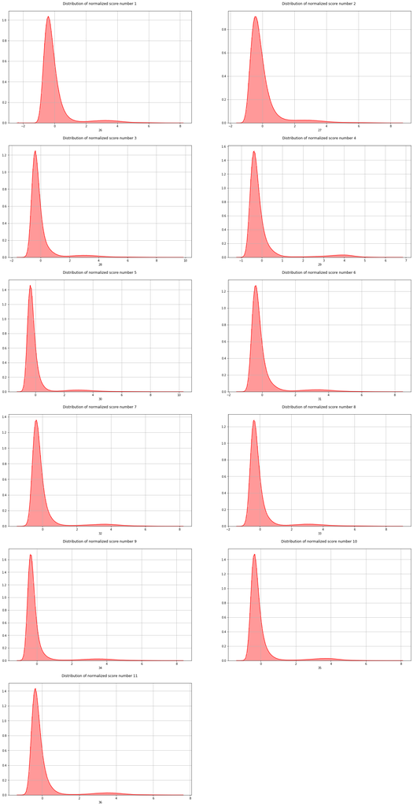

```python
plt.figure(figsize=(25,50))
for i in range(1,12):
    plt.subplot(6,2,i)
    sns.distplot(xtrain[25+i], bins=200, color='red')
    plt.title("Distribution of normalized score number {} \n".format(i))
    plt.grid(True)

plt.show()
```

## Train test split before cross validation on k-folds (in XGBoost)

[figure not shown]

```python
# Processing train test split
xtrain_cv, xtest_cv, ytrain_cv, ytest_cv = train_test_split(xtrain, ytrain, test_size=0.2, random_state=42)
```

```python
xtrain_cv.describe()
```

|  | 0 | 1 | 2 | 3 | 4 | 5 | 6 | 7 | 8 | 9 | 10 | 11 | 12 | 13 | 14 | 15 | 16 | 17 | 18 | 19 | 20 | 21 | 22 | 23 | 24 | 25 | 26 | 27 | 28 | … |
| --- | --- | --- | --- | --- | --- | --- | --- | --- | --- | --- | --- | --- | --- | --- | --- | --- | --- | --- | --- | --- | --- | --- | --- | --- | --- | --- | --- | --- | --- | --- |
| count | 7.840570e+06 | 7.840570e+06 | 7.840570e+06 | 7.840570e+06 | 7.840570e+06 | 7.840570e+06 | 7.840570e+06 | 7.840570e+06 | 7.840570e+06 | 7.840570e+06 | 7.840570e+06 | 7.840570e+06 | 7.840570e+06 | 7.840570e+06 | 7.840570e+06 | 7.840570e+06 | 7.840570e+06 | 7.840570e+06 | 7.840570e+06 | 7.840570e+06 | 7.840570e+06 | 7.840570e+06 | 7.840570e+06 | 7.840570e+06 | 7.840570e+06 | 7.840570e+06 | 7.840570e+06 | 7.840570e+06 | 7.840570e+06 | … |
| mean | 9.918550e-01 | 5.237098e-03 | 2.855408e-03 | -2.250510e-01 | -5.767197e+00 | -7.427788e-01 | 1.264651e+00 | 9.991066e-01 | 8.595021e-01 | 2.561090e+02 | 3.765353e+01 | 1.872971e-01 | 7.033921e-01 | 9.970559e-01 | 4.047576e-03 | 1.506078e-03 | -1.990065e-01 | -5.785732e+00 | -7.614514e-01 | 1.220407e+00 | 9.556454e-01 | 8.158552e-01 | 2.685551e+02 | 3.805995e+01 | 1.780516e-01 | 7.261337e-01 | -4.023386e-04 | -4.028414e-04 | -4.155512e-04 | … |
| std | 6.368566e-02 | 5.133087e-02 | 3.607134e-02 | 9.949731e+00 | 8.868083e+00 | 4.565739e+00 | 1.158562e+00 | 8.947627e-01 | 7.738624e-01 | 7.511772e+01 | 1.340607e+01 | 3.894991e-01 | 4.488066e-01 | 6.295002e-01 | 5.656401e-01 | 2.342917e-02 | 8.444217e+00 | 8.350760e+00 | 4.387696e+00 | 1.095579e+00 | 8.641712e-01 | 8.051271e-01 | 7.494516e+01 | 1.359791e+01 | 3.820760e-01 | 4.374798e-01 | 9.994154e-01 | 9.993446e-01 | 9.990642e-01 | … |
| min | 0.000000e+00 | 0.000000e+00 | 0.000000e+00 | -7.820000e+01 | -6.771000e+01 | -3.482000e+01 | 0.000000e+00 | 0.000000e+00 | 0.000000e+00 | -2.980000e+02 | 1.842000e+01 | 0.000000e+00 | 0.000000e+00 | 0.000000e+00 | 0.000000e+00 | 0.000000e+00 | -5.476000e+01 | -4.213000e+01 | -2.640000e+01 | 0.000000e+00 | 0.000000e+00 | 0.000000e+00 | -2.980000e+02 | 1.846000e+01 | 0.000000e+00 | 0.000000e+00 | -2.336386e+00 | -1.556905e+00 | -1.585433e+00 | … |
| 25% | 1.000000e+00 | 0.000000e+00 | 0.000000e+00 | -3.220000e+00 | -1.263000e+01 | -2.850000e+00 | 4.700000e-01 | 3.500000e-01 | 3.100000e-01 | 2.112800e+02 | 2.580000e+01 | 0.000000e+00 | 1.000000e-02 | 1.000000e+00 | 0.000000e+00 | 0.000000e+00 | -2.580000e+00 | -1.241000e+01 | -2.750000e+00 | 4.500000e-01 | 3.300000e-01 | 2.900000e-01 | 2.245700e+02 | 2.578000e+01 | 0.000000e+00 | 4.000000e-02 | -5.083235e-01 | -5.413195e-01 | -4.750517e-01 | … |
| 50% | 1.000000e+00 | 0.000000e+00 | 0.000000e+00 | -1.000000e-02 | -4.870000e+00 | -6.000000e-01 | 1.000000e+00 | 7.600000e-01 | 6.700000e-01 | 2.641500e+02 | 3.449000e+01 | 0.000000e+00 | 1.000000e+00 | 1.000000e+00 | 0.000000e+00 | 0.000000e+00 | 5.000000e-02 | -4.910000e+00 | -6.400000e-01 | 9.600000e-01 | 7.200000e-01 | 6.400000e-01 | 2.773900e+02 | 3.521000e+01 | 0.000000e+00 | 1.000000e+00 | -2.616158e-01 | -2.613013e-01 | -2.703403e-01 | … |
| 75% | 1.000000e+00 | 0.000000e+00 | 0.000000e+00 | 3.140000e+00 | 9.500000e-01 | 1.430000e+00 | 1.740000e+00 | 1.380000e+00 | 1.190000e+00 | 3.091200e+02 | 4.808000e+01 | 0.000000e+00 | 1.000000e+00 | 1.000000e+00 | 0.000000e+00 | 0.000000e+00 | 2.610000e+00 | 7.600000e-01 | 1.240000e+00 | 1.690000e+00 | 1.320000e+00 | 1.130000e+00 | 3.216400e+02 | 4.895000e+01 | 0.000000e+00 | 1.000000e+00 | 8.277567e-02 | 1.369642e-01 | 2.455240e-02 | … |
| max | 1.000000e+00 | 1.000000e+00 | 1.000000e+00 | 5.934000e+01 | 2.668000e+01 | 6.482000e+01 | 3.873000e+01 | 1.568000e+01 | 2.442000e+01 | 4.704700e+02 | 7.677000e+01 | 1.000000e+00 | 1.000000e+00 | 2.602500e+02 | 2.331300e+02 | 9.800000e-01 | 5.108000e+01 | 2.277000e+01 | 2.474000e+01 | 3.001000e+01 | 9.430000e+00 | 1.452100e+02 | 1.611470e+03 | 7.677000e+01 | 1.000000e+00 | 1.000000e+00 | 8.147333e+00 | 8.692212e+00 | 9.808352e+00 | … |

```python
xtest_cv.describe()
```

|  | 0 | 1 | 2 | 3 | 4 | 5 | 6 | 7 | 8 | 9 | 10 | 11 | 12 | 13 | 14 | 15 | 16 | 17 | 18 | 19 | 20 | 21 | 22 | 23 | 24 | 25 | 26 | 27 | 28 | … |
| --- | --- | --- | --- | --- | --- | --- | --- | --- | --- | --- | --- | --- | --- | --- | --- | --- | --- | --- | --- | --- | --- | --- | --- | --- | --- | --- | --- | --- | --- | --- |
| count | 1.960143e+06 | 1.960143e+06 | 1.960143e+06 | 1.960143e+06 | 1.960143e+06 | 1.960143e+06 | 1.960143e+06 | 1.960143e+06 | 1.960143e+06 | 1.960143e+06 | 1.960143e+06 | 1.960143e+06 | 1.960143e+06 | 1.960143e+06 | 1.960143e+06 | 1.960143e+06 | 1.960143e+06 | 1.960143e+06 | 1.960143e+06 | 1.960143e+06 | 1.960143e+06 | 1.960143e+06 | 1.960143e+06 | 1.960143e+06 | 1.960143e+06 | 1.960143e+06 | 1.960143e+06 | 1.960143e+06 | 1.960143e+06 | … |
| mean | 9.917623e-01 | 5.314189e-03 | 2.871051e-03 | -2.216708e-01 | -5.765152e+00 | -7.402397e-01 | 1.264387e+00 | 9.994277e-01 | 8.583422e-01 | 2.560665e+02 | 3.764895e+01 | 1.874010e-01 | 7.029664e-01 | 9.984937e-01 | 5.254122e-03 | 1.507313e-03 | -2.046139e-01 | -5.796177e+00 | -7.648305e-01 | 1.219478e+00 | 9.548220e-01 | 8.166947e-01 | 2.685818e+02 | 3.806125e+01 | 1.782563e-01 | 7.258417e-01 | 1.609354e-03 | 1.611365e-03 | 1.662204e-03 | … |
| std | 6.411502e-02 | 5.183972e-02 | 3.610070e-02 | 9.964009e+00 | 8.872178e+00 | 4.565498e+00 | 1.158934e+00 | 8.949679e-01 | 7.712193e-01 | 7.516476e+01 | 1.339987e+01 | 3.895783e-01 | 4.489580e-01 | 8.696399e-01 | 7.816963e-01 | 2.341997e-02 | 8.448713e+00 | 8.354102e+00 | 4.386910e+00 | 1.094969e+00 | 8.643610e-01 | 8.717991e-01 | 7.504416e+01 | 1.359757e+01 | 3.822519e-01 | 4.376072e-01 | 1.002334e+00 | 1.002616e+00 | 1.003733e+00 | … |
| min | 0.000000e+00 | 0.000000e+00 | 0.000000e+00 | -7.820000e+01 | -6.771000e+01 | -3.390000e+01 | 0.000000e+00 | 0.000000e+00 | 0.000000e+00 | -2.980000e+02 | 1.842000e+01 | 0.000000e+00 | 0.000000e+00 | 0.000000e+00 | 0.000000e+00 | 0.000000e+00 | -5.476000e+01 | -4.213000e+01 | -2.640000e+01 | 0.000000e+00 | 0.000000e+00 | 0.000000e+00 | -2.980000e+02 | 1.846000e+01 | 0.000000e+00 | 0.000000e+00 | -2.336386e+00 | -1.479936e+00 | -1.498363e+00 | … |
| 25% | 1.000000e+00 | 0.000000e+00 | 0.000000e+00 | -3.210000e+00 | -1.263000e+01 | -2.840000e+00 | 4.700000e-01 | 3.500000e-01 | 3.100000e-01 | 2.111700e+02 | 2.581000e+01 | 0.000000e+00 | 1.000000e-02 | 1.000000e+00 | 0.000000e+00 | 0.000000e+00 | -2.580000e+00 | -1.243000e+01 | -2.750000e+00 | 4.500000e-01 | 3.300000e-01 | 2.900000e-01 | 2.246800e+02 | 2.578000e+01 | 0.000000e+00 | 4.000000e-02 | -5.079280e-01 | -5.410049e-01 | -4.746787e-01 | … |
| 50% | 1.000000e+00 | 0.000000e+00 | 0.000000e+00 | -1.000000e-02 | -4.890000e+00 | -6.000000e-01 | 1.000000e+00 | 7.600000e-01 | 6.700000e-01 | 2.640800e+02 | 3.448000e+01 | 0.000000e+00 | 1.000000e+00 | 1.000000e+00 | 0.000000e+00 | 0.000000e+00 | 5.000000e-02 | -4.920000e+00 | -6.400000e-01 | 9.600000e-01 | 7.200000e-01 | 6.400000e-01 | 2.774300e+02 | 3.521000e+01 | 0.000000e+00 | 1.000000e+00 | -2.609598e-01 | -2.606616e-01 | -2.703086e-01 | … |
| 75% | 1.000000e+00 | 0.000000e+00 | 0.000000e+00 | 3.140000e+00 | 9.600000e-01 | 1.430000e+00 | 1.740000e+00 | 1.380000e+00 | 1.190000e+00 | 3.091700e+02 | 4.807000e+01 | 0.000000e+00 | 1.000000e+00 | 1.000000e+00 | 0.000000e+00 | 0.000000e+00 | 2.610000e+00 | 7.500000e-01 | 1.230000e+00 | 1.690000e+00 | 1.320000e+00 | 1.130000e+00 | 3.218000e+02 | 4.894000e+01 | 0.000000e+00 | 1.000000e+00 | 8.457963e-02 | 1.381021e-01 | 2.515556e-02 | … |
| max | 1.000000e+00 | 1.000000e+00 | 1.000000e+00 | 5.933000e+01 | 2.668000e+01 | 6.482000e+01 | 3.873000e+01 | 1.568000e+01 | 2.442000e+01 | 4.657700e+02 | 7.677000e+01 | 1.000000e+00 | 1.000000e+00 | 2.602500e+02 | 2.331300e+02 | 9.800000e-01 | 5.108000e+01 | 2.277000e+01 | 2.474000e+01 | 3.001000e+01 | 9.430000e+00 | 1.452100e+02 | 1.611470e+03 | 7.677000e+01 | 1.000000e+00 | 1.000000e+00 | 8.147333e+00 | 8.394910e+00 | 8.717169e+00 | … |

```python
ytrain_cv.describe()
```

|  | 0 |
| --- | --- |
| count | 7.840570e+06 |
| mean | 6.857359e-02 |
| std | 2.527276e-01 |
| min | 0.000000e+00 |
| 25% | 0.000000e+00 |
| 50% | 0.000000e+00 |
| 75% | 0.000000e+00 |
| max | 1.000000e+00 |

```python
ytest_cv.describe()
```

|  | 0 |
| --- | --- |
| count | 1.960143e+06 |
| mean | 6.907455e-02 |
| std | 2.535809e-01 |
| min | 0.000000e+00 |
| 25% | 0.000000e+00 |
| 50% | 0.000000e+00 |
| 75% | 0.000000e+00 |
| max | 1.000000e+00 |

# **PCA to reduce dimension**

The following code blocks can perform a PCA on the training dataset.

Since we have 13 qualities per images and 11 scoring results, let's start with generate, from the original 37 dimensions, the first 3 principal components, that means one per images plus one for scores.

```python
from sklearn.decomposition import PCA

df = pd.DataFrame() # transitionnal df 1
df2 = pd.DataFrame() # transitionnal df 2

# Image 1
pca1 = PCA(n_components=1)
pca1_result = pca1.fit_transform(xtrain_cv.iloc[:, 0:12].values)
pca1_result2 = pca1.fit_transform(xtest_cv.iloc[:, 0:12].values)

df['pca-1'] = pca1_result[:,0]
df2['pca-1'] = pca1_result2[:,0]

# Image 2
pca2 = PCA(n_components=1)
pca2_result = pca2.fit_transform(xtrain_cv.iloc[:, 13:25].values)
pca2_result2 = pca2.fit_transform(xtest_cv.iloc[:, 13:25].values)

df['pca-2'] = pca2_result[:,0]
df2['pca-2'] = pca2_result2[:,0]

# Image 3
pca3 = PCA(n_components=1)
pca3_result = pca3.fit_transform(xtrain_cv.iloc[:, 26:36].values)
pca3_result2 = pca3.fit_transform(xtest_cv.iloc[:, 26:36].values)

df['pca-3'] = pca3_result[:,0]
df2['pca-3'] = pca3_result2[:,0]
```

```python
df.head()
```

|  | pca-1 | pca-2 | pca-3 |
| --- | --- | --- | --- |
| 0 | -40.170445 | 27.282616 | 240.558724 |
| 1 | 109.075512 | 44.470197 | -1814.353697 |
| 2 | 53.926923 | -87.739237 | -1705.359731 |
| 3 | 24.397128 | -4.370603 | -231.500976 |
| 4 | -13.569028 | 73.897543 | -974.756452 |

```python
df.describe()
```

|  | pca-1 | pca-2 | pca-3 |
| --- | --- | --- | --- |
| count | 7.840570e+06 | 7.840570e+06 | 7.840570e+06 |
| mean | -1.532918e-13 | 1.906554e-13 | 4.879792e-12 |
| std | 7.515514e+01 | 7.496290e+01 | 3.910193e+03 |
| min | -2.146664e+02 | -5.670290e+02 | -4.903747e+03 |
| 25% | -5.304578e+01 | -4.395647e+01 | -1.685520e+03 |
| 50% | -8.009579e+00 | 8.853814e+00 | -1.177762e+03 |
| 75% | 4.477652e+01 | 5.314479e+01 | -2.758178e+02 |
| max | 5.545624e+02 | 1.342952e+03 | 3.267028e+04 |

```python
xtrain_cv = pd.DataFrame.copy(df)
xtest_cv = pd.DataFrame.copy(df2)
```

# **Train a simple classifier : Logit Regression**

```python
# Train the classifier on a part of the data set
clf = LogisticRegression(solver='lbfgs', max_iter = 200)
clf.fit(xtrain_cv, ytrain_cv, )
```

```
LogisticRegression(C=1.0, class_weight=None, dual=False, fit_intercept=True,
                   intercept_scaling=1, l1_ratio=None, max_iter=200,
                   multi_class='auto', n_jobs=None, penalty='l2',
                   random_state=None, solver='lbfgs', tol=0.0001, verbose=0,
                   warm_start=False)
```

```python
# Check its on another part of the data set
yvalid = clf.predict_proba(xtest_cv)[:,xgb.classes_ == 1][:,0]
print(yvalid)
```

```
[1.17897778e-05 8.74504249e-05 3.63186283e-05 ... 6.82991168e-05
 2.38042911e-04 3.07984592e-06]
```

```python
# Calculate the performance metric
yvalid_scoreordered = ytest_cv.values[np.argsort(yvalid)]
print(yvalid_scoreordered)
N = np.sum(ytest_cv.values == 0)
P = np.sum(ytest_cv.values == 1)
FP = 0
TP = 0
for i in range(ytest_cv.shape[0] - 1, -1, -1):
    if (yvalid_scoreordered[i] == 1):
        TP = TP + 1
    else:
        FP = FP + 1
    if (FP / N > 10**-4):
        FP = FP - 1
        break
print("For the smallest FPR <= 10^-4 (i.e., ", FP / N, ") TPR = ", TP / P, ".", sep = "")
```

```
[[1]
 [1]
 [1]
 ...
 [1]
 [1]
 [1]]
For the smallest FPR <= 10^-4 (i.e., 9.973985434693138e-05) TPR = 0.8745014623770274.
```

# **Personnal work on XGBoost classifier**

## XGBoost's hyperparameters tuning with K-folds and Grid Search

At this point, before building the model, we should be aware of the tuning parameters that XGBoost provides. Well, there are a plethora of tuning parameters for tree-based learners in XGBoost and we can read all about them here. But the most common ones that we should know are :

- `learning_rate` : step size shrinkage used to prevent overfitting. Range is $[0,1]$.
- `max_depth` (default=3) : determines how deeply each tree is allowed to grow during any boosting round. Increasing this value will make the model more complex and more likely to overfit. Beware that XGBoost aggressively consumes memory when training a deep tree.
- `subsample` : percentage of samples used per tree. Low value can lead to underfitting.
- `colsample_bytree` : percentage of features used per tree. High value can lead to overfitting (default 1).
- `n_estimators` : number of trees we want to build.
- `objective` : determines the loss function to be used like `reg:linear` for regression problems, `reg:logistic` for classification problems with only decision, `binary:logistic` (default) for classification problems with probability.

XGBoost also supports regularization parameters to penalize models as they become more complex and reduce them to simple (parsimonious) models.

- `gamma` : controls whether a given node will split based on the expected reduction in loss after the split. A higher value leads to fewer splits. Supported only for tree-based learners. So the larger gamma is, the more conservative the algorithm will be. Range is $[0,∞]$.
- `alpha` : L1 regularization on leaf weights. A large value leads to more regularization.
- `lambda` : L2 regularization on leaf weights and is smoother than L1 regularization.

It's also worth mentioning that though we are using trees as our base learners, we can also use XGBoost's relatively less popular linear base learners and one other tree learner known as dart. All we have to do is set the `booster` parameter to either `gbtree` (default), `gblinear` or `dart`.

```python
import warnings
warnings.filterwarnings('ignore')
from datetime import datetime
from sklearn.model_selection import RandomizedSearchCV, GridSearchCV
#from sklearn.metrics import roc_auc_score
from sklearn.model_selection import StratifiedKFold
import xgboost
from xgboost import XGBClassifier
```

```python
def timer(start_time=None):
    if not start_time:
        start_time = datetime.now()
        return start_time
    elif start_time:
        thour, temp_sec = divmod((datetime.now() - start_time).total_seconds(), 3600)
        tmin, tsec = divmod(temp_sec, 60)
        print('\n Time taken: %i hours %i minutes and %s seconds.' % (thour, tmin, round(tsec, 2)))

# A parameter grid for XGBoost
params = {
        'min_child_weight': [2, 5, 7, 8],
        'gamma': [1, 1.5, 2, 3, 5],
        'subsample': [0.4, 0.6, 0.8],
        'colsample_bytree': [0.6, 0.8, 1.0, 1.2],
        'n_estimators': [400, 600, 700],
        'max_depth': [3, 4, 5, 6]
        }
```

```python
xgb = XGBClassifier(objective='binary:logistic', verbose=True,
                    learning_rate=0.05, n_jobs=-1, tree_method='gpu_hist')
```

```python
nrows_train = 4000000

folds = 10
param_comb = 10

skf = StratifiedKFold(n_splits=folds, shuffle = True, random_state = 42)

random_search = RandomizedSearchCV(xgb, param_distributions=params, n_iter=param_comb,
                                  scoring='roc_auc', n_jobs=-1, cv=skf.split(xtrain_cv[:nrows_train],
                                  ytrain_cv[:nrows_train]), verbose=10, random_state=42 )

# Here we go
start_time = timer(None) # timing starts from this point for "start_time" variable
random_search.fit(xtrain_cv[:nrows_train], ytrain_cv[:nrows_train])
timer(start_time) # timing ends here for "start_time" variable
```

```
Fitting 10 folds for each of 10 candidates, totalling 100 fits
```

```
[Parallel(n_jobs=-1)]: Using backend LokyBackend with 4 concurrent workers.
[Parallel(n_jobs=-1)]: Done   5 tasks      | elapsed:  4.8min
[Parallel(n_jobs=-1)]: Done  10 tasks      | elapsed:  7.3min
[Parallel(n_jobs=-1)]: Done  17 tasks      | elapsed: 12.9min
[Parallel(n_jobs=-1)]: Done  24 tasks      | elapsed: 16.0min
[Parallel(n_jobs=-1)]: Done  33 tasks      | elapsed: 23.0min
[Parallel(n_jobs=-1)]: Done  42 tasks      | elapsed: 27.2min
[Parallel(n_jobs=-1)]: Done  53 tasks      | elapsed: 28.8min
[Parallel(n_jobs=-1)]: Done  64 tasks      | elapsed: 31.5min
[Parallel(n_jobs=-1)]: Done  77 tasks      | elapsed: 39.2min
[Parallel(n_jobs=-1)]: Done  90 tasks      | elapsed: 46.2min
[Parallel(n_jobs=-1)]: Done 100 out of 100 | elapsed: 51.3min finished
```

```
 Time taken: 0 hours 52 minutes and 0.56 seconds.
```

> **Note that the ROC_AUC metric is used because it is ultimately the one that comes closest to the metric that we are trying to optimize.** It would have been perfect to be able to use the challenge metrics directly in the grid search.

```python
print('\n All results:')
print(random_search.cv_results_)
print('\n Best estimator:')
print(random_search.best_estimator_)
print('\n Best normalized gini score for %d-fold search with %d parameter combinations:' % (folds, param_comb))
print(random_search.best_score_ * 2 - 1)
print('\n Best hyperparameters:')
print(random_search.best_params_)
results = pd.DataFrame(random_search.cv_results_)
results.to_csv('xgb-random-grid-search-results-01.csv', index=False)
```

[output not shown]

## Training a classifier on the biggest dataset possible and with the best parameters

The following code blocks can be use to retrain the classifier with the best parameters on a bigger set of train data.

```python
# Training a classifier with the best parameters
xgb = random_search.best_estimator_
```

```python
## Re-Processing train test split if wanted
# xtrain_cv, xtest_cv, ytrain_cv, ytest_cv = train_test_split(xtrain, ytrain, test_size=0.3, random_state=42)

# Here we go
start_time = timer(None) # timing starts from this point for "start_time" variable
xgb.fit(xtrain_cv, ytrain_cv)
timer(start_time) # timing ends here for "start_time" variable
```

```
 Time taken: 0 hours 1 minutes and 19.23 seconds.
```

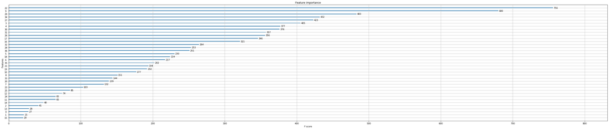

```python
# Ploting the feature importance
xgboost.plot_importance(xgb)
plt.rcParams['figure.figsize'] = [50, 10]
plt.show()
```

> We therefore see that in our model, column 9 of image 1 and column 22 of image 2 (which are the associated columns) are the most important in the decisions.

```python
xgboost.plot_tree(xgb,num_trees=0)
plt.show()
```

[output not shown]

## Made prediction with the best estimators

The following code can be only use to make prediction with the best classifier model.

```python
yvalid = xgb.predict_proba(xtest_cv)[:,xgb.classes_ == 1][:,0]
print(yvalid)
```

```
[7.9645861e-06 8.2802844e-06 1.0814750e-06 ... 1.6179384e-04 8.4571930e-06
 2.0052008e-02]
```

```python
# Calculate the performance metric
yvalid_scoreordered = ytest_cv.values[np.argsort(yvalid)]
print(yvalid_scoreordered)
N = np.sum(ytest_cv.values == 0)
P = np.sum(ytest_cv.values == 1)
FP = 0
TP = 0
for i in range(ytest_cv.shape[0] - 1, -1, -1):
    if (yvalid_scoreordered[i] == 1):
        TP = TP + 1
    else:
        FP = FP + 1
    if (FP / N > 10**-4):
        FP = FP - 1
        break
print("For the smallest FPR <= 10^-4 (i.e., ", FP / N, ") TPR = ", TP / P, ".", sep = "")
```

```
[[0]
 [0]
 [0]
 ...
 [1]
 [1]
 [1]]
For the smallest FPR <= 10^-4 (i.e., 9.972551738548187e-05) TPR = 0.9659250123334978.
```

# **Prepare a file for submission**

> **Beware of normalizing test scores** before doing predictions if normalized scores were used to train the classifier !! The remark is the same for the PCA. Test data must be transform before using the predictor :

```
# PCA on test set
df3 = pd.DataFrame() # transitionnal df 1

# Image 1
pca4 = PCA(n_components=1)
pca4_result = pca4.fit_transform(xtest.iloc[:, 0:12].values)

df3['pca-1'] = pca4_result[:,0]


# Image 2
pca5 = PCA(n_components=1)
pca5_result = pca5.fit_transform(xtest.iloc[:, 13:25].values)

df3['pca-2'] = pca5_result[:,0]

# Image 3
pca6 = PCA(n_components=1)
pca6_result = pca6.fit_transform(xtest.iloc[:, 26:36].values)

df3['pca-3'] = pca6_result[:,0]

xtest = pd.DataFrame.copy(df3)
```

```python
# Load test data
xtest = pd.read_csv(path+'xtest_challenge.csv', delimiter=',', skiprows = 1, header=None)

# Classify the provided test data
ytest = xgb.predict_proba(xtest)[:,xgb.classes_ == 1][:,0]
print(ytest.shape)
np.savetxt(path+'ytest_challenge_student.csv', ytest, fmt = '%1.15f', delimiter=',')
```

```
(3768311,)
```